# Visualizing Tennis Grand Slam Winners Performances

Giorgio Garziano

May 2, 2017

## Introduction

Data visualization of sports historical results is one of the means by which champions strengths and weaknesses comparison can be outlined. In this tutorial, we show what plots flavors may help in champions performances comparison, timeline visualization, player-to-player and player-to-tournament relationships. We are going to use the Tennis Grand Slam Tournaments results as outlined by the ESP site at: [ESPN site tennis history table](http://www.espn.com/tennis/history) and which has been made available as tab-delimited file at the following link: [tennis-grand-slam-winners](https://datascienceplus.com/wp-content/uploads/2017/04/tennis-grand-slam-winners.txt)

Our analysis shall involve basic dataset manipulation as well. Overall, we are going to take advantage of the following R packages:

`library(ggplot2)` #for barplots  
`library(gplots)` #for heatmaps  
`library(RColorBrewer)` #for palettes  
`library(dplyr)` #for dataset manipulation  
`library(knitr)` #for neaty dataset printing  
`library(timelineS)` #for timeline plot  
`library(circlize)` #for chord-diagrams  
`library(fmsb)` #for radar plots

## Analysis

Loading R libraries and importing the Tennis Grand Slam Winners dataset.

```r
library_toload <-
  c(
  "dplyr",
  "knitr",
  "ggplot2",
  "gplots",
  "RColorBrewer",
  "timelineS",
  "circlize",
  "fmsb"
  )
  invisible(lapply(library_toload, function(x) {
  suppressPackageStartupMessages(library(x, character.only = TRUE))
  }))


  url_file <- "https://datascienceplus.com/wp-content/uploads/2017/04/tennis-grand-slam-winners.txt"
  slam_win <-  read.delim(url(url_file), sep = "\t", stringsAsFactors = FALSE)
  kable(head(slam_win, 20))
```

[output not shown]

```r
slam_win[grep("Australian Open", slam_win$TOURNAMENT), "TOURNAMENT"] = "Australian Open"
```

## Barplot

Grouping by winner and summarising the number of wins are preliminary steps in order to compute a table where each champion name is associated to his own number of Tennis Grand Slam wins.

```r
slam_top_chart <- slam_win %>%
  group_by(WINNER) %>%
  summarise(NUM_WINS = n()) %>%
  arrange(desc(NUM_WINS))

kable(head(slam_top_chart, 40))
```

| WINNER | NUM_WINS |
| --- | --- |
| Roger Federer | 18 |
| Pete Sampras | 14 |
| Rafael Nadal | 14 |
| Novak Djokovic | 12 |
| Roy Emerson | 12 |
| Bjorn Borg | 11 |
| Rod Laver | 11 |
| William T. Tilden | 10 |
| Andre Agassi | 8 |
| Fred Perry | 8 |
| Henri Cochet | 8 |
| Ivan Lendl | 8 |
| Jimmy Connors | 8 |
| Ken Rosewall | 8 |
| Max Decugis | 8 |
| William A. Larned | 8 |
| John McEnroe | 7 |
| John Newcombe | 7 |
| Mats Wilander | 7 |
| Rene Lacoste | 7 |
| Richard D. Sears | 7 |
| William Renshaw | 7 |
| Boris Becker | 6 |
| Donald Budge | 6 |
| Stefan Edberg | 6 |
| Frank Sedgman | 5 |
| Jack Crawford | 5 |
| Jean Borotra | 5 |
| Laurie Doherty | 5 |
| Tony Trabert | 5 |
| Andre Vacherot | 4 |
| Anthony Wilding | 4 |
| Ashley J. Cooper | 4 |
| Frank Parker | 4 |
| Guillermo Vilas | 4 |
| Jim Courier | 4 |
| Lewis Hoad | 4 |
| Manuel Santana | 4 |
| Pat O’Hara Wood | 4 |
| Paul Ayme | 4 |

To graphically introduce such table, a barplot reporting winners ordered by their number of wins is suggestable. In that way, we can evaluate the players performance from the absolute perspective and relative to each other. Our barplot involves the champions who won at least four Tennis Grand Slam tournaments.

[figure not shown]

```r
slam_top_chart$WINNER <-
  factor(slam_top_chart$WINNER, levels = slam_top_chart$WINNER[order(slam_top_chart$NUM_WINS)])

top_winners_gt4 <-  slam_top_chart %>%
                    filter(NUM_WINS >= 4)
the_colours <-  c(
  "#FF4000FF",
  "#FF8000FF",
  "#FFFF00FF",
  "#80FF00FF",
  "#00FF00FF",
  "#00FF80FF",
  "#00FFFFFF",
  "#0080FFFF",
  "#FF00FFFF",
  "#000000FF",
  "#0000FFFF"
  )

ggplot(data = top_winners_gt4, aes(x = WINNER, y = NUM_WINS, fill = NUM_WINS)) +
  geom_bar(stat = 'identity') + coord_flip() + guides(fill = FALSE) +
  scale_fill_gradientn(colours = the_colours)
```

Further, to facilitate comparison of champions’ performances for each specific tournament, the grouping by TOURNAMENT and WINNER is necessary.

```r
slam_top_chart_by_trn <-  slam_win %>%
  filter(WINNER %in% top_winners_gt4$WINNER) %>%
  group_by(TOURNAMENT, WINNER) %>%
  summarise(NUM_WINS = n()) %>%
  arrange(desc(NUM_WINS))

slam_top_chart_by_trn$NUM_WINS <- factor(slam_top_chart_by_trn$NUM_WINS)

kable(head(slam_top_chart_by_trn, 10))
```

| TOURNAMENT | WINNER | NUM_WINS |
| --- | --- | --- |
| French Open | Rafael Nadal | 9 |
| French Open | Max Decugis | 8 |
| U.S. Open | William A. Larned | 8 |
| U.S. Open | Richard D. Sears | 7 |
| U.S. Open | William T. Tilden | 7 |
| Wimbledon | Pete Sampras | 7 |
| Wimbledon | Roger Federer | 7 |
| Wimbledon | William Renshaw | 7 |
| Australian Open | Novak Djokovic | 6 |
| Australian Open | Roy Emerson | 6 |

To obtain the required barplot flavor, we take specifically advantage of the discrete scale for y axis and the facet_grid based on the TOURNAMENT field.

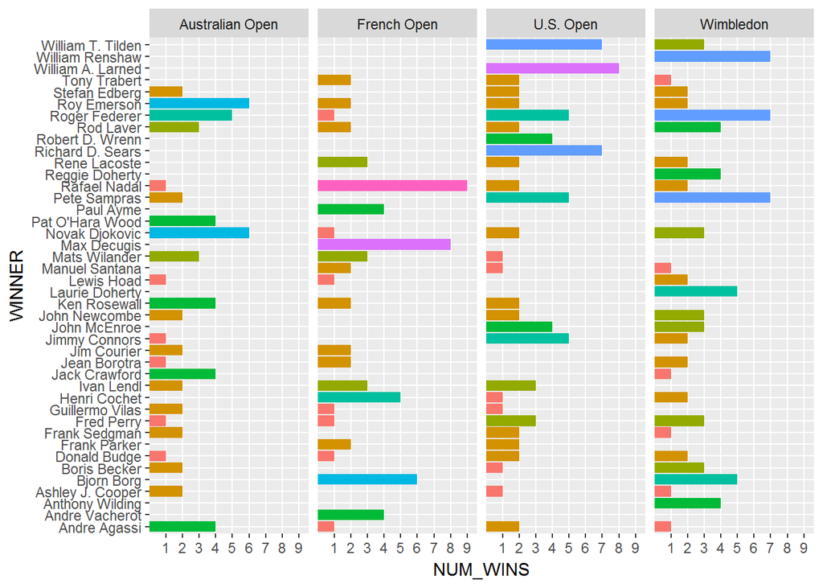

```r
ggplot(data = slam_top_chart_by_trn, aes(x = WINNER, y = NUM_WINS, fill = NUM_WINS)) +
  geom_bar(stat = 'identity') + coord_flip() + guides(fill = FALSE) + scale_y_discrete() +
  facet_grid(. ~ TOURNAMENT)
```